# Differential Gene Expression Analysis

Colorectal Cancer | Necroptosis, Ferroptosis & Pyroptosis

Kim Williame Lee[^1]

Mark Edward M. Gonzales[^2]

Dr. Anish M.S. Shrestha[^3]

## I. Preliminaries

### Loading libraries

```r
library("tidyverse")
library("tibble")
library("msigdbr")
library("ggplot2")
library("TCGAbiolinks")
library("RNAseqQC")
library("DESeq2")
library("ensembldb")
library("purrr")
library("magrittr")
library("vsn")
library("matrixStats")
library("dplyr")
library("grex")
```

## II. Downloading TCGA gene expression data

Download gene expression data from The Cancer Genome Atlas (TCGA): - `TCGA-COAD` refers to the biospecimen data for colon adenocarcinoma. - `STAR - Counts` pertains to the raw counts.

```r
query_tumor <- GDCquery(
  project = "TCGA-COAD",
  data.category = "Transcriptome Profiling",
  data.type = "Gene Expression Quantification",
  experimental.strategy = "RNA-Seq",
  workflow.type = "STAR - Counts",
  access = "open",
  sample.type = "Primary Tumor"
)
tumor <- getResults(query_tumor)
tumor
```

|  | id | data_format | cases | access | file_name | submitter_id | data_category | type | platform | file_size | created_datetime | md5sum | updated_datetime | file_id | data_type | state | experimental_strategy | version | data_release | project | analysis_id | analysis_state | analysis_submitter_id | analysis_workflow_link | analysis_workflow_type | analysis_workflow_version | sample_type | is_ffpe | cases.submitter_id | … |
| --- | --- | --- | --- | --- | --- | --- | --- | --- | --- | --- | --- | --- | --- | --- | --- | --- | --- | --- | --- | --- | --- | --- | --- | --- | --- | --- | --- | --- | --- | --- |
| 1 | 534054c8-b88f-4b5f-b718-f4ca8484b83c | TSV | TCGA-AA-3692-01A-01R-0905-07 | open | 4d33ae3d-d6e6-47cd-bb5d-52134a7bcf8d.rna_seq.augmented_star_gene_counts.tsv | cf853c78-c86f-4711-af16-1fb9013eb90f | Transcriptome Profiling | gene_expression | Illumina | 4222918 | 2022-01-05T19:17:42.483015-06:00 | afbb60e489571ba198ef474274c50ace | 2024-07-30T16:12:17.931101-05:00 | 534054c8-b88f-4b5f-b718-f4ca8484b83c | Gene Expression Quantification | released | RNA-Seq | 1 | 32.0 - 41.0 | TCGA-COAD | ecacdb5e-dadd-4676-80a8-d3bc65009de1 | released | 4d33ae3d-d6e6-47cd-bb5d-52134a7bcf8d_star__counts | quay.io/ncigdc | STAR - Counts | 470801dfbc085958058a5b50518e4f3a5e4721c3 | Primary Tumor | NA | TCGA-AA-3692 | … |
| 2 | 82aa9226-61c4-4cd7-9138-5199e7c85e6a | TSV | TCGA-AA-A00L-01A-01R-A002-07 | open | e0c9f612-91a0-4b84-b3d5-665514324cb6.rna_seq.augmented_star_gene_counts.tsv | 559f1147-2d93-49e8-a8ac-2fa8445b8d17 | Transcriptome Profiling | gene_expression | Illumina | 4205198 | 2022-01-05T19:15:44.611022-06:00 | 436ee62f67c6de271428ce908ae32267 | 2024-07-30T16:27:37.286374-05:00 | 82aa9226-61c4-4cd7-9138-5199e7c85e6a | Gene Expression Quantification | released | RNA-Seq | 1 | 32.0 - 41.0 | TCGA-COAD | ee88234d-89ae-4a45-81c9-d12f3ae149c0 | released | e0c9f612-91a0-4b84-b3d5-665514324cb6_star__counts | quay.io/ncigdc | STAR - Counts | 470801dfbc085958058a5b50518e4f3a5e4721c3 | Primary Tumor | NA | TCGA-AA-A00L | … |
| 3 | 228b425f-ddc8-46e4-b246-41f4389b7a97 | TSV | TCGA-G4-6625-01A-21R-1774-07 | open | cfbdbfeb-7550-46dc-bd3b-bf85c4a14443.rna_seq.augmented_star_gene_counts.tsv | 2ad48868-89d8-4331-be33-2ddd64c326e1 | Transcriptome Profiling | gene_expression | Illumina | 4237552 | 2022-01-05T19:24:13.691653-06:00 | 02cfad62cf2c22bee50b4786f6d51d7d | 2024-07-30T16:28:14.201034-05:00 | 228b425f-ddc8-46e4-b246-41f4389b7a97 | Gene Expression Quantification | released | RNA-Seq | 1 | 32.0 - 41.0 | TCGA-COAD | eebfecd5-70da-4490-8eb8-b52ec9d650df | released | cfbdbfeb-7550-46dc-bd3b-bf85c4a14443_star__counts | https://github.com/NCI-GDC/gdc-rnaseq-cwl/blob/5d8c131bbff59fb0c969217fc1d44e6d1503cd1f/rnaseq-star-align/star2pass.rnaseq_harmonization.cwl | STAR - Counts | 5d8c131bbff59fb0c969217fc1d44e6d1503cd1f | Primary Tumor | NA | TCGA-G4-6625 | … |
| 4 | 41a9b39d-c8b3-4b5f-9c1f-952ac04cb441 | TSV | TCGA-AA-3522-01A-01R-0821-07 | open | e59f49c0-d7ce-44c3-9590-9b65128d7f8b.rna_seq.augmented_star_gene_counts.tsv | 20dab9c6-e43f-4d97-a102-c301cc2ee6bb | Transcriptome Profiling | gene_expression | Illumina | 4208044 | 2022-01-05T19:11:14.322813-06:00 | a9005116ed24a8d93b00ec9f2b5de030 | 2024-07-30T16:12:16.656115-05:00 | 41a9b39d-c8b3-4b5f-9c1f-952ac04cb441 | Gene Expression Quantification | released | RNA-Seq | 1 | 32.0 - 41.0 | TCGA-COAD | d27d6e5c-767c-4ad2-869a-d6d4e6fab2ef | released | e59f49c0-d7ce-44c3-9590-9b65128d7f8b_star__counts | quay.io/ncigdc | STAR - Counts | 470801dfbc085958058a5b50518e4f3a5e4721c3 | Primary Tumor | NA | TCGA-AA-3522 | … |
| 5 | 359bacfe-23d1-4d3b-870e-8f98982540ce | TSV | TCGA-CM-4750-01A-01R-1410-07 | open | 48128da3-329b-45c5-be65-c8cbeccddb97.rna_seq.augmented_star_gene_counts.tsv | 59ad278d-e72d-47cd-84c6-1025e96f8454 | Transcriptome Profiling | gene_expression | Illumina | 4206013 | 2022-01-05T19:10:18.005487-06:00 | 05ddd18011466a4938adf8e43fb40de5 | 2024-07-30T16:26:06.771826-05:00 | 359bacfe-23d1-4d3b-870e-8f98982540ce | Gene Expression Quantification | released | RNA-Seq | 1 | 32.0 - 41.0 | TCGA-COAD | a65e6fea-6141-4720-814d-21e694a540f4 | released | 48128da3-329b-45c5-be65-c8cbeccddb97_star__counts | quay.io/ncigdc | STAR - Counts | 470801dfbc085958058a5b50518e4f3a5e4721c3 | Primary Tumor | NA | TCGA-CM-4750 | … |
| 6 | d49d7f13-243f-4840-97bf-371d862c8de5 | TSV | TCGA-AA-3554-01A-01R-0826-07 | open | 24d909f2-cdc8-4509-91d5-e18fffcf90eb.rna_seq.augmented_star_gene_counts.tsv | 3f5dd84e-553e-4f8d-a03d-4bea55b3d539 | Transcriptome Profiling | gene_expression | Illumina | 4211856 | 2022-01-05T19:10:56.343611-06:00 | cad784b354f21be6ae8bec4d669c8834 | 2024-07-30T16:09:27.967429-05:00 | d49d7f13-243f-4840-97bf-371d862c8de5 | Gene Expression Quantification | released | RNA-Seq | 1 | 32.0 - 41.0 | TCGA-COAD | 2b01b2a7-c9bf-4dd9-b080-a6fdc603b120 | released | 24d909f2-cdc8-4509-91d5-e18fffcf90eb_star__counts | quay.io/ncigdc | STAR - Counts | 470801dfbc085958058a5b50518e4f3a5e4721c3 | Primary Tumor | NA | TCGA-AA-3554 | … |
| 7 | ff710149-0fc6-464a-93cb-e3b9bdcf3525 | TSV | TCGA-AA-3561-01A-01R-0821-07 | open | dfb9c45f-cb52-4e36-b663-1a9e8c7c0b47.rna_seq.augmented_star_gene_counts.tsv | f1c2f95b-2faa-4dd2-8505-57c793e920e5 | Transcriptome Profiling | gene_expression | Illumina | 4204474 | 2022-01-05T19:10:30.906217-06:00 | 0322f762090e53965c964b763ce9cd7c | 2024-07-30T16:28:51.150303-05:00 | ff710149-0fc6-464a-93cb-e3b9bdcf3525 | Gene Expression Quantification | released | RNA-Seq | 1 | 32.0 - 41.0 | TCGA-COAD | a6d3becf-a9b2-4640-8a2b-f0b4c97bbf00 | released | dfb9c45f-cb52-4e36-b663-1a9e8c7c0b47_star__counts | quay.io/ncigdc | STAR - Counts | 470801dfbc085958058a5b50518e4f3a5e4721c3 | Primary Tumor | NA | TCGA-AA-3561 | … |
| 8 | 56b924c9-299d-41a1-b3fb-38586051a26e | TSV | TCGA-G4-6307-01A-11R-1723-07 | open | 63bab58e-1dfd-43df-8188-4b8d766913f3.rna_seq.augmented_star_gene_counts.tsv | 0fe2a73a-0d77-439e-a808-652750558d83 | Transcriptome Profiling | gene_expression | Illumina | 4242335 | 2022-01-05T19:25:54.970316-06:00 | 0e90423ca12788a2cf789604bf9dc217 | 2024-07-30T16:25:55.969039-05:00 | 56b924c9-299d-41a1-b3fb-38586051a26e | Gene Expression Quantification | released | RNA-Seq | 1 | 32.0 - 41.0 | TCGA-COAD | 2a87b983-4512-4fbb-88a9-ae8bce459406 | released | 63bab58e-1dfd-43df-8188-4b8d766913f3_star__counts | https://github.com/NCI-GDC/gdc-rnaseq-cwl/blob/5d8c131bbff59fb0c969217fc1d44e6d1503cd1f/rnaseq-star-align/star2pass.rnaseq_harmonization.cwl | STAR - Counts | 5d8c131bbff59fb0c969217fc1d44e6d1503cd1f | Primary Tumor | NA | TCGA-G4-6307 | … |
| 9 | d2bb361b-c78c-482f-b4d4-bd77ac7c0f37 | TSV | TCGA-A6-6781-01A-22R-A278-07 | open | ad478846-0a75-4081-ac09-37ee5415d9b4.rna_seq.augmented_star_gene_counts.tsv | 586dbc42-9960-44c0-af30-ce82f88c40e6 | Transcriptome Profiling | gene_expression | Illumina | 4214802 | 2022-01-05T19:27:12.715828-06:00 | 416206d3b70b5194128826a4f42ab670 | 2024-07-30T16:26:49.647194-05:00 | d2bb361b-c78c-482f-b4d4-bd77ac7c0f37 | Gene Expression Quantification | released | RNA-Seq | 1 | 32.0 - 41.0 | TCGA-COAD | 6758a6fd-39d0-4970-8d77-e24330cd9461 | released | ad478846-0a75-4081-ac09-37ee5415d9b4_star__counts | https://github.com/NCI-GDC/gdc-rnaseq-cwl/blob/5d8c131bbff59fb0c969217fc1d44e6d1503cd1f/rnaseq-star-align/star2pass.rnaseq_harmonization.cwl | STAR - Counts | 5d8c131bbff59fb0c969217fc1d44e6d1503cd1f | Primary Tumor | NA | TCGA-A6-6781 | … |
| 10 | 025bf99d-1e89-43f3-b0b7-8dfe5d43e192 | TSV | TCGA-AY-A8YK-01A-11R-A41B-07 | open | 690d4959-780e-4783-8a90-268159abefb1.rna_seq.augmented_star_gene_counts.tsv | 134e3c9a-4850-4469-ae60-c95ba6cd68e0 | Transcriptome Profiling | gene_expression | Illumina | 4233560 | 2022-01-05T19:07:10.283180-06:00 | de2df44cfa886b92fde2af6150562de1 | 2024-07-30T16:11:30.889744-05:00 | 025bf99d-1e89-43f3-b0b7-8dfe5d43e192 | Gene Expression Quantification | released | RNA-Seq | 1 | 32.0 - 41.0 | TCGA-COAD | b2acc9f0-707a-4705-bf0d-e9b2c1a22631 | released | 690d4959-780e-4783-8a90-268159abefb1_star__counts | https://github.com/NCI-GDC/gdc-rnaseq-cwl/blob/5d8c131bbff59fb0c969217fc1d44e6d1503cd1f/rnaseq-star-align/star2pass.rnaseq_harmonization.cwl | STAR - Counts | 5d8c131bbff59fb0c969217fc1d44e6d1503cd1f | Primary Tumor | NA | TCGA-AY-A8YK | … |

[output cut: 471 more lines]

```r
query_normal <- GDCquery(
  project = "TCGA-COAD",
  data.category = "Transcriptome Profiling",
  data.type = "Gene Expression Quantification",
  experimental.strategy = "RNA-Seq",
  workflow.type = "STAR - Counts",
  access = "open",
  sample.type = "Solid Tissue Normal"
)
normal <- getResults(query_normal)
normal
```

|  | id | data_format | cases | access | file_name | submitter_id | data_category | type | platform | file_size | created_datetime | md5sum | updated_datetime | file_id | data_type | state | experimental_strategy | version | data_release | project | analysis_id | analysis_state | analysis_submitter_id | analysis_workflow_link | analysis_workflow_type | analysis_workflow_version | sample_type | is_ffpe | cases.submitter_id | … |
| --- | --- | --- | --- | --- | --- | --- | --- | --- | --- | --- | --- | --- | --- | --- | --- | --- | --- | --- | --- | --- | --- | --- | --- | --- | --- | --- | --- | --- | --- | --- |
| 1 | c63c52c9-82ba-46f8-bd0c-9459f25e98f2 | TSV | TCGA-AA-3662-11A-01R-1723-07 | open | ed61dd33-6f80-4998-a0fb-82498e123505.rna_seq.augmented_star_gene_counts.tsv | 80de6ed8-a882-4bb4-a052-5688ab507bba | Transcriptome Profiling | gene_expression | Illumina | 4232317 | 2022-01-05T19:08:30.830542-06:00 | d7ca460b131a0bd120cb18c097c5ec8d | 2024-07-30T16:09:26.693798-05:00 | c63c52c9-82ba-46f8-bd0c-9459f25e98f2 | Gene Expression Quantification | released | RNA-Seq | 1 | 32.0 - 41.0 | TCGA-COAD | 0e848723-e2b4-4e64-a6f1-ff9e530edff7 | released | ed61dd33-6f80-4998-a0fb-82498e123505_star__counts | https://github.com/NCI-GDC/gdc-rnaseq-cwl/blob/5d8c131bbff59fb0c969217fc1d44e6d1503cd1f/rnaseq-star-align/star2pass.rnaseq_harmonization.cwl | STAR - Counts | 5d8c131bbff59fb0c969217fc1d44e6d1503cd1f | Solid Tissue Normal | NA | TCGA-AA-3662 | … |
| 2 | 8eaead17-aacf-49b0-9f62-30fb80df9df3 | TSV | TCGA-AA-3531-11A-01R-A32Z-07 | open | 871b21df-9338-419b-a2cc-9cf1552f4da2.rna_seq.augmented_star_gene_counts.tsv | 6b279fea-4812-4fdb-815b-546238abade9 | Transcriptome Profiling | gene_expression | Illumina | 4234303 | 2022-01-05T19:29:55.252748-06:00 | 6a405361d20c45f13565ef301046c598 | 2024-07-30T16:28:36.268705-05:00 | 8eaead17-aacf-49b0-9f62-30fb80df9df3 | Gene Expression Quantification | released | RNA-Seq | 1 | 32.0 - 41.0 | TCGA-COAD | a5588d04-9248-4c62-ad04-a6842f7a566f | released | 871b21df-9338-419b-a2cc-9cf1552f4da2_star__counts | https://github.com/NCI-GDC/gdc-rnaseq-cwl/blob/5d8c131bbff59fb0c969217fc1d44e6d1503cd1f/rnaseq-star-align/star2pass.rnaseq_harmonization.cwl | STAR - Counts | 5d8c131bbff59fb0c969217fc1d44e6d1503cd1f | Solid Tissue Normal | NA | TCGA-AA-3531 | … |
| 3 | a06c89f2-be32-4102-b126-45dcfd364dae | TSV | TCGA-AZ-6603-11A-02R-1839-07 | open | c4464d1a-4513-44af-a555-68cd0ca584b1.rna_seq.augmented_star_gene_counts.tsv | 050ed740-76fa-4436-a76e-1111267a176b | Transcriptome Profiling | gene_expression | Illumina | 4235514 | 2022-01-05T19:07:42.326263-06:00 | 696c65d850518927d5420209ae6018d6 | 2024-07-30T16:27:12.356220-05:00 | a06c89f2-be32-4102-b126-45dcfd364dae | Gene Expression Quantification | released | RNA-Seq | 1 | 32.0 - 41.0 | TCGA-COAD | b5e6a3f8-0545-4d69-ba33-7a695c94e358 | released | c4464d1a-4513-44af-a555-68cd0ca584b1_star__counts | https://github.com/NCI-GDC/gdc-rnaseq-cwl/blob/5d8c131bbff59fb0c969217fc1d44e6d1503cd1f/rnaseq-star-align/star2pass.rnaseq_harmonization.cwl | STAR - Counts | 5d8c131bbff59fb0c969217fc1d44e6d1503cd1f | Solid Tissue Normal | NA | TCGA-AZ-6603 | … |
| 4 | d0b39c4a-a06f-4c52-84b4-3c6483651685 | TSV | TCGA-AZ-6599-11A-01R-1774-07 | open | 572c3cf7-a0df-40d2-bc64-3fde805c72a7.rna_seq.augmented_star_gene_counts.tsv | 675042be-16b3-40de-88f8-0ce72e4ea111 | Transcriptome Profiling | gene_expression | Illumina | 4240257 | 2022-01-05T19:21:32.282358-06:00 | 660673269afee49bf58a112b8e3af6d4 | 2024-07-30T16:20:59.286672-05:00 | d0b39c4a-a06f-4c52-84b4-3c6483651685 | Gene Expression Quantification | released | RNA-Seq | 1 | 32.0 - 41.0 | TCGA-COAD | 7d27b796-ec65-4bf6-a12e-fc93d6537aec | released | 572c3cf7-a0df-40d2-bc64-3fde805c72a7_star__counts | https://github.com/NCI-GDC/gdc-rnaseq-cwl/blob/5d8c131bbff59fb0c969217fc1d44e6d1503cd1f/rnaseq-star-align/star2pass.rnaseq_harmonization.cwl | STAR - Counts | 5d8c131bbff59fb0c969217fc1d44e6d1503cd1f | Solid Tissue Normal | NA | TCGA-AZ-6599 | … |
| 5 | dc0b07cb-49fb-44d0-b4d0-e99d50532d6d | TSV | TCGA-AA-3655-11A-01R-1723-07 | open | c0529681-133f-47a6-bb6d-cd10c738524b.rna_seq.augmented_star_gene_counts.tsv | fbbbf9b2-404a-44ba-893e-ae24c2991771 | Transcriptome Profiling | gene_expression | Illumina | 4234053 | 2022-01-05T19:21:49.257676-06:00 | 91c3d6b0c1cdad4e1e118812dd9572be | 2024-07-30T16:08:13.473691-05:00 | dc0b07cb-49fb-44d0-b4d0-e99d50532d6d | Gene Expression Quantification | released | RNA-Seq | 1 | 32.0 - 41.0 | TCGA-COAD | 2f879e89-5a49-40f4-a773-4d7a3cd4977f | released | c0529681-133f-47a6-bb6d-cd10c738524b_star__counts | https://github.com/NCI-GDC/gdc-rnaseq-cwl/blob/5d8c131bbff59fb0c969217fc1d44e6d1503cd1f/rnaseq-star-align/star2pass.rnaseq_harmonization.cwl | STAR - Counts | 5d8c131bbff59fb0c969217fc1d44e6d1503cd1f | Solid Tissue Normal | NA | TCGA-AA-3655 | … |
| 6 | bdb54e47-4d66-4ca2-9709-e17c808c606f | TSV | TCGA-A6-5665-11A-01R-1653-07 | open | c4438838-dcf9-47bb-b796-4a37dbfa369b.rna_seq.augmented_star_gene_counts.tsv | b9670532-cbcf-411e-93c7-9997c570c110 | Transcriptome Profiling | gene_expression | Illumina | 4223427 | 2022-01-05T19:08:14.438258-06:00 | a61b248a5459cba110a2792fd0bf5df8 | 2024-07-30T16:20:27.671347-05:00 | bdb54e47-4d66-4ca2-9709-e17c808c606f | Gene Expression Quantification | released | RNA-Seq | 1 | 32.0 - 41.0 | TCGA-COAD | 2da46fca-05bc-47cf-b0f1-d26506845f0b | released | c4438838-dcf9-47bb-b796-4a37dbfa369b_star__counts | https://github.com/NCI-GDC/gdc-rnaseq-cwl/blob/5d8c131bbff59fb0c969217fc1d44e6d1503cd1f/rnaseq-star-align/star2pass.rnaseq_harmonization.cwl | STAR - Counts | 5d8c131bbff59fb0c969217fc1d44e6d1503cd1f | Solid Tissue Normal | NA | TCGA-A6-5665 | … |
| 7 | 530bff57-a892-435d-94df-ddc7dbd45fb9 | TSV | TCGA-A6-2686-11A-01R-A32Z-07 | open | ba6ae99d-73a8-48a5-b038-749434ae2f11.rna_seq.augmented_star_gene_counts.tsv | 0345695a-714c-42a6-bf81-cce2587af049 | Transcriptome Profiling | gene_expression | Illumina | 4237522 | 2022-01-05T19:43:12.411547-06:00 | d6bb414eb7f4f3645e3608cbb29c60c0 | 2024-07-30T16:23:47.022098-05:00 | 530bff57-a892-435d-94df-ddc7dbd45fb9 | Gene Expression Quantification | released | RNA-Seq | 1 | 32.0 - 41.0 | TCGA-COAD | 281e1e7f-c1e2-4c41-a836-ec1974d48261 | released | ba6ae99d-73a8-48a5-b038-749434ae2f11_star__counts | https://github.com/NCI-GDC/gdc-rnaseq-cwl/blob/5d8c131bbff59fb0c969217fc1d44e6d1503cd1f/rnaseq-star-align/star2pass.rnaseq_harmonization.cwl | STAR - Counts | 5d8c131bbff59fb0c969217fc1d44e6d1503cd1f | Solid Tissue Normal | NA | TCGA-A6-2686 | … |
| 8 | 026818a6-8180-4d9c-9357-b88a832b374e | TSV | TCGA-A6-5659-11A-01R-1653-07 | open | d4d783e3-e8df-4cbd-9f8a-53120abf58a1.rna_seq.augmented_star_gene_counts.tsv | 81820cdf-3558-4d71-9d75-134c97e456d1 | Transcriptome Profiling | gene_expression | Illumina | 4211909 | 2022-01-05T19:15:13.360608-06:00 | 99d83193b0bc66f217ae1d1686611665 | 2024-07-30T16:13:51.146521-05:00 | 026818a6-8180-4d9c-9357-b88a832b374e | Gene Expression Quantification | released | RNA-Seq | 1 | 32.0 - 41.0 | TCGA-COAD | 5d688f14-22bf-45f9-ad13-3915281015aa | released | d4d783e3-e8df-4cbd-9f8a-53120abf58a1_star__counts | https://github.com/NCI-GDC/gdc-rnaseq-cwl/blob/5d8c131bbff59fb0c969217fc1d44e6d1503cd1f/rnaseq-star-align/star2pass.rnaseq_harmonization.cwl | STAR - Counts | 5d8c131bbff59fb0c969217fc1d44e6d1503cd1f | Solid Tissue Normal | NA | TCGA-A6-5659 | … |
| 9 | ee9a460d-1b5e-451e-8b4b-7608a21f093d | TSV | TCGA-A6-2684-11A-01R-A32Z-07 | open | c1b43ace-3691-4c64-9fb1-4c1e94735b1e.rna_seq.augmented_star_gene_counts.tsv | c5b2ec6e-6f38-4507-9cb4-e8b91ade9fa3 | Transcriptome Profiling | gene_expression | Illumina | 4229253 | 2022-01-05T19:22:09.150788-06:00 | 484c67fb0444a8cff0b6b6ff1fcf36b2 | 2024-07-30T16:17:24.870845-05:00 | ee9a460d-1b5e-451e-8b4b-7608a21f093d | Gene Expression Quantification | released | RNA-Seq | 1 | 32.0 - 41.0 | TCGA-COAD | 3bf5f5ff-317f-406e-9b82-a9eb3a2a685c | released | c1b43ace-3691-4c64-9fb1-4c1e94735b1e_star__counts | https://github.com/NCI-GDC/gdc-rnaseq-cwl/blob/5d8c131bbff59fb0c969217fc1d44e6d1503cd1f/rnaseq-star-align/star2pass.rnaseq_harmonization.cwl | STAR - Counts | 5d8c131bbff59fb0c969217fc1d44e6d1503cd1f | Solid Tissue Normal | NA | TCGA-A6-2684 | … |
| 10 | f90ba917-21bf-4822-bc55-00f933c9ec34 | TSV | TCGA-AZ-6598-11A-01R-1774-07 | open | b12ce56d-b73f-4a80-8d53-08fc1ac97ccb.rna_seq.augmented_star_gene_counts.tsv | c6610b4c-6e03-4ff5-bd4f-dadd8f06653f | Transcriptome Profiling | gene_expression | Illumina | 4238907 | 2022-01-05T19:20:04.056372-06:00 | 0d2010be57b663501775dc8ddf9c7810 | 2024-07-30T16:11:50.727587-05:00 | f90ba917-21bf-4822-bc55-00f933c9ec34 | Gene Expression Quantification | released | RNA-Seq | 1 | 32.0 - 41.0 | TCGA-COAD | 2ee8dc21-3e99-49ec-a6c3-9f0112ff4bbe | released | b12ce56d-b73f-4a80-8d53-08fc1ac97ccb_star__counts | https://github.com/NCI-GDC/gdc-rnaseq-cwl/blob/5d8c131bbff59fb0c969217fc1d44e6d1503cd1f/rnaseq-star-align/star2pass.rnaseq_harmonization.cwl | STAR - Counts | 5d8c131bbff59fb0c969217fc1d44e6d1503cd1f | Solid Tissue Normal | NA | TCGA-AZ-6598 | … |

[output cut: 31 more lines]

Consider only samples with both normal and malignant tissues.

```r
submitter_ids <- inner_join(tumor, normal, by = "cases.submitter_id") %>%
  dplyr::select(cases.submitter_id)
tumor <- tumor %>%
  dplyr::filter(cases.submitter_id %in% submitter_ids$cases.submitter_id)
normal <- normal %>%
  dplyr::filter(cases.submitter_id %in% submitter_ids$cases.submitter_id)

samples <- rbind(tumor, normal)
invisible(unique(samples$sample_type))
samples
```

| id | data_format | cases | access | file_name | submitter_id | data_category | type | platform | file_size | created_datetime | md5sum | updated_datetime | file_id | data_type | state | experimental_strategy | version | data_release | project | analysis_id | analysis_state | analysis_submitter_id | analysis_workflow_link | analysis_workflow_type | analysis_workflow_version | sample_type | is_ffpe | cases.submitter_id | sample.submitter_id |
| --- | --- | --- | --- | --- | --- | --- | --- | --- | --- | --- | --- | --- | --- | --- | --- | --- | --- | --- | --- | --- | --- | --- | --- | --- | --- | --- | --- | --- | --- |
| 41a9b39d-c8b3-4b5f-9c1f-952ac04cb441 | TSV | TCGA-AA-3522-01A-01R-0821-07 | open | e59f49c0-d7ce-44c3-9590-9b65128d7f8b.rna_seq.augmented_star_gene_counts.tsv | 20dab9c6-e43f-4d97-a102-c301cc2ee6bb | Transcriptome Profiling | gene_expression | Illumina | 4208044 | 2022-01-05T19:11:14.322813-06:00 | a9005116ed24a8d93b00ec9f2b5de030 | 2024-07-30T16:12:16.656115-05:00 | 41a9b39d-c8b3-4b5f-9c1f-952ac04cb441 | Gene Expression Quantification | released | RNA-Seq | 1 | 32.0 - 41.0 | TCGA-COAD | d27d6e5c-767c-4ad2-869a-d6d4e6fab2ef | released | e59f49c0-d7ce-44c3-9590-9b65128d7f8b_star__counts | quay.io/ncigdc | STAR - Counts | 470801dfbc085958058a5b50518e4f3a5e4721c3 | Primary Tumor | NA | TCGA-AA-3522 | TCGA-AA-3522-01A |
| ac731d82-8a46-4e68-baba-401977b5ac9f | TSV | TCGA-A6-2678-01A-01R-0821-07 | open | cb6e4e0c-6f89-4ea5-a89d-1b0da8cf7fac.rna_seq.augmented_star_gene_counts.tsv | daa2891d-de78-450f-b099-8993090a4b39 | Transcriptome Profiling | gene_expression | Illumina | 4217179 | 2022-01-05T19:15:33.018970-06:00 | 91cc095a9b069119b6a18cb5e51c6dde | 2024-07-30T16:16:39.617944-05:00 | ac731d82-8a46-4e68-baba-401977b5ac9f | Gene Expression Quantification | released | RNA-Seq | 1 | 32.0 - 41.0 | TCGA-COAD | 5526e1b7-83f9-4cd8-9a4c-740f0f3ddd82 | released | cb6e4e0c-6f89-4ea5-a89d-1b0da8cf7fac_star__counts | quay.io/ncigdc | STAR - Counts | 470801dfbc085958058a5b50518e4f3a5e4721c3 | Primary Tumor | NA | TCGA-A6-2678 | TCGA-A6-2678-01A |
| 985d5043-cf68-4f4b-bba1-1aa621ab20c9 | TSV | TCGA-A6-5665-01B-03R-2302-07 | open | ec48e2b8-ca0a-40fe-a87b-f0e955466840.rna_seq.augmented_star_gene_counts.tsv | dc5cf41b-3561-4d06-bd80-8f9008bc377a | Transcriptome Profiling | gene_expression | Illumina | 4235818 | 2022-01-05T19:14:39.426451-06:00 | 0483e650f8bee65d5925816d3e9c93a6 | 2024-07-30T16:18:52.040721-05:00 | 985d5043-cf68-4f4b-bba1-1aa621ab20c9 | Gene Expression Quantification | released | RNA-Seq | 1 | 32.0 - 41.0 | TCGA-COAD | e02eaf4d-0a60-4fb9-a2ce-f7bee8bbfe65 | released | ec48e2b8-ca0a-40fe-a87b-f0e955466840_star__counts | https://github.com/NCI-GDC/gdc-rnaseq-cwl/blob/5d8c131bbff59fb0c969217fc1d44e6d1503cd1f/rnaseq-star-align/star2pass.rnaseq_harmonization.cwl | STAR - Counts | 5d8c131bbff59fb0c969217fc1d44e6d1503cd1f | Primary Tumor | NA | TCGA-A6-5665 | TCGA-A6-5665-01B |
| 13a72fbf-f601-4f67-aca4-796716f78293 | TSV | TCGA-AZ-6600-01A-11R-1774-07 | open | 9ef8ac96-eaba-447f-ac45-aa44f2182c50.rna_seq.augmented_star_gene_counts.tsv | 82dfdc30-7a17-4fc6-956f-65ff9def1e91 | Transcriptome Profiling | gene_expression | Illumina | 4239225 | 2022-01-05T19:33:04.584004-06:00 | 7eb0a8da95109011efe0bd8f14773554 | 2024-07-30T02:14:09.504226-05:00 | 13a72fbf-f601-4f67-aca4-796716f78293 | Gene Expression Quantification | released | RNA-Seq | 1 | 32.0 - 41.0 | TCGA-COAD | 7b929a3d-7908-4684-8df6-20b95f993fae | released | 9ef8ac96-eaba-447f-ac45-aa44f2182c50_star__counts | https://github.com/NCI-GDC/gdc-rnaseq-cwl/blob/5d8c131bbff59fb0c969217fc1d44e6d1503cd1f/rnaseq-star-align/star2pass.rnaseq_harmonization.cwl | STAR - Counts | 5d8c131bbff59fb0c969217fc1d44e6d1503cd1f | Primary Tumor | NA | TCGA-AZ-6600 | TCGA-AZ-6600-01A |
| 97dbbc5d-67e7-43a0-bc8f-d3425e0f3ce4 | TSV | TCGA-A6-2684-01A-01R-1410-07 | open | 6bc70f5c-fdba-4bef-865a-793b7782a107.rna_seq.augmented_star_gene_counts.tsv | f5f0b9b6-1dee-47d3-81de-4cfbb809328b | Transcriptome Profiling | gene_expression | Illumina | 4206565 | 2022-01-05T19:31:12.287412-06:00 | a563e864dbf3f1ee17abf3df9abc5719 | 2024-07-30T16:08:56.734834-05:00 | 97dbbc5d-67e7-43a0-bc8f-d3425e0f3ce4 | Gene Expression Quantification | released | RNA-Seq | 1 | 32.0 - 41.0 | TCGA-COAD | 5cc52f59-fef6-49b1-b914-8aa7a95db6a6 | released | 6bc70f5c-fdba-4bef-865a-793b7782a107_star__counts | quay.io/ncigdc | STAR - Counts | 470801dfbc085958058a5b50518e4f3a5e4721c3 | Primary Tumor | NA | TCGA-A6-2684 | TCGA-A6-2684-01A |
| 4781cfea-da20-42ff-aefe-2eaa168f9e34 | TSV | TCGA-AZ-6605-01A-11R-1839-07 | open | c277dab0-361f-4aa6-96b1-522a6e556ae1.rna_seq.augmented_star_gene_counts.tsv | 758bbd0b-0495-45ce-abae-e5a5d9d3f6e6 | Transcriptome Profiling | gene_expression | Illumina | 4235863 | 2022-01-05T19:38:44.690177-06:00 | 9155a12d5a03fcc07b43556a362d30af | 2024-07-30T16:21:39.816022-05:00 | 4781cfea-da20-42ff-aefe-2eaa168f9e34 | Gene Expression Quantification | released | RNA-Seq | 1 | 32.0 - 41.0 | TCGA-COAD | ef514d0b-fc0e-402b-9f97-41fda946c9c3 | released | c277dab0-361f-4aa6-96b1-522a6e556ae1_star__counts | https://github.com/NCI-GDC/gdc-rnaseq-cwl/blob/5d8c131bbff59fb0c969217fc1d44e6d1503cd1f/rnaseq-star-align/star2pass.rnaseq_harmonization.cwl | STAR - Counts | 5d8c131bbff59fb0c969217fc1d44e6d1503cd1f | Primary Tumor | NA | TCGA-AZ-6605 | TCGA-AZ-6605-01A |
| bdc3b4bb-dea2-4e41-b297-51540a68e68c | TSV | TCGA-AA-3489-01A-21R-1839-07 | open | 09f3976d-4e95-41b4-bc0b-27eea3e20bb3.rna_seq.augmented_star_gene_counts.tsv | 075a90bd-5cdd-4e65-8d03-c3831f3b6c36 | Transcriptome Profiling | gene_expression | Illumina | 4248591 | 2022-01-05T19:21:58.831767-06:00 | 8929598ec17454b0485feb4b45e368eb | 2024-07-30T16:19:56.736280-05:00 | bdc3b4bb-dea2-4e41-b297-51540a68e68c | Gene Expression Quantification | released | RNA-Seq | 1 | 32.0 - 41.0 | TCGA-COAD | be415689-6562-4a71-8afd-389c83ee3202 | released | 09f3976d-4e95-41b4-bc0b-27eea3e20bb3_star__counts | https://github.com/NCI-GDC/gdc-rnaseq-cwl/blob/5d8c131bbff59fb0c969217fc1d44e6d1503cd1f/rnaseq-star-align/star2pass.rnaseq_harmonization.cwl | STAR - Counts | 5d8c131bbff59fb0c969217fc1d44e6d1503cd1f | Primary Tumor | NA | TCGA-AA-3489 | TCGA-AA-3489-01A |
| e3526436-feca-4475-95d2-cdb1f861dac9 | TSV | TCGA-AA-3517-01A-01R-0821-07 | open | 670152b4-944c-4d41-a9ce-c6c8ad616de0.rna_seq.augmented_star_gene_counts.tsv | 23b6bd05-3c8d-45ad-a1e3-be822fb7c960 | Transcriptome Profiling | gene_expression | Illumina | 4213187 | 2022-01-05T19:08:51.420690-06:00 | ac737ddc1f9ac9db1eb2eddd27ed8399 | 2024-07-30T16:14:53.285421-05:00 | e3526436-feca-4475-95d2-cdb1f861dac9 | Gene Expression Quantification | released | RNA-Seq | 1 | 32.0 - 41.0 | TCGA-COAD | d0434d18-09d9-4ea3-9001-e461e8c02c91 | released | 670152b4-944c-4d41-a9ce-c6c8ad616de0_star__counts | quay.io/ncigdc | STAR - Counts | 470801dfbc085958058a5b50518e4f3a5e4721c3 | Primary Tumor | NA | TCGA-AA-3517 | TCGA-AA-3517-01A |
| 2c15e60c-1190-4bcd-88df-d0707d737a17 | TSV | TCGA-AA-3518-01A-02R-0826-07 | open | 7c8246a6-3f2c-42e1-b09f-959cfbf7fd5a.rna_seq.augmented_star_gene_counts.tsv | 676594c7-7537-4380-b588-0f29131fb720 | Transcriptome Profiling | gene_expression | Illumina | 4211542 | 2022-01-05T19:09:59.714913-06:00 | 45fafba3480185a37554beafc6010e90 | 2024-07-30T16:12:42.244195-05:00 | 2c15e60c-1190-4bcd-88df-d0707d737a17 | Gene Expression Quantification | released | RNA-Seq | 1 | 32.0 - 41.0 | TCGA-COAD | fedd0e82-0239-4617-b379-3967f9d61485 | released | 7c8246a6-3f2c-42e1-b09f-959cfbf7fd5a_star__counts | quay.io/ncigdc | STAR - Counts | 470801dfbc085958058a5b50518e4f3a5e4721c3 | Primary Tumor | NA | TCGA-AA-3518 | TCGA-AA-3518-01A |
| 94f29a8c-1dcb-44ff-a96b-e9267ec84347 | TSV | TCGA-A6-2683-01A-01R-0821-07 | open | 299f36bd-d9fd-41f5-8a29-3382e147a14f.rna_seq.augmented_star_gene_counts.tsv | e56851f3-7021-4ba4-b71d-f6f1ee36fb43 | Transcriptome Profiling | gene_expression | Illumina | 4194221 | 2022-01-05T19:16:55.317762-06:00 | 50a01be631a5c8a87a3c8bafce06f544 | 2024-07-30T16:25:27.936441-05:00 | 94f29a8c-1dcb-44ff-a96b-e9267ec84347 | Gene Expression Quantification | released | RNA-Seq | 1 | 32.0 - 41.0 | TCGA-COAD | e69f0ef1-78f8-4e1d-8697-eb7c84712a04 | released | 299f36bd-d9fd-41f5-8a29-3382e147a14f_star__counts | quay.io/ncigdc | STAR - Counts | 470801dfbc085958058a5b50518e4f3a5e4721c3 | Primary Tumor | NA | TCGA-A6-2683 | TCGA-A6-2683-01A |

[output cut: 77 more lines]

Download only samples with both normal and malignant tissues.

To impose this filtering, we set the `barcode` argument of `GDCquery` to `samples$sample.submitter_id` (which was generated in the previous cell).

```r
query_coad <- GDCquery(
  project = "TCGA-COAD",
  data.category = "Transcriptome Profiling",
  data.type = "Gene Expression Quantification",
  experimental.strategy = "RNA-Seq",
  workflow.type = "STAR - Counts",
  access = "open",
  sample.type = c("Solid Tissue Normal", "Primary Tumor"),
  barcode = as.list(samples$sample.submitter_id)
)
```

If this is your first time running this notebook (i.e., you have not yet downloaded the results of the query in the previous block), uncomment the code block below.

```r
# GDCdownload(query_coad)
```

Running the code block above should generate and populate a directory named `GDCdata`.

## III. Data preprocessing

Construct the RNA-seq count matrix.

```r
tcga_coad_data <- GDCprepare(query_coad, summarizedExperiment = TRUE)
```

```r
count_matrix <- assay(tcga_coad_data, "unstranded")

# Remove duplicate entries
count_matrix_df <- data.frame(count_matrix)
count_matrix_df <- count_matrix_df[!duplicated(count_matrix_df), ]
count_matrix <- data.matrix(count_matrix_df)
rownames(count_matrix) <- cleanid(rownames(count_matrix))
count_matrix <- count_matrix[!(duplicated(rownames(count_matrix)) | duplicated(rownames(count_matrix), fromLast = TRUE)), ]

head(count_matrix[1:5, 1:4])
```

```
                TCGA.AA.3522.01A.01R.0821.07 TCGA.A6.2678.01A.01R.0821.07 TCGA.A6.5665.01B.03R.2302.07 TCGA.AZ.6600.01A.11R.1774.07
ENSG00000000003                         4069                         4088                          670                         3195
ENSG00000000005                           22                           38                           10                           14
ENSG00000000419                         1070                         1577                          535                         2460
ENSG00000000457                          386                          625                          425                          624
ENSG00000000460                          166                          441                          253                          467
```

Format the `samples` table so that it can be fed as input to DESeq2.

```r
rownames(samples) <- samples$cases
samples <- samples %>%
  dplyr::select(case = "cases.submitter_id", type = "sample_type")
samples$type <- str_replace(samples$type, "Solid Tissue Normal", "normal")
samples$type <- str_replace(samples$type, "Primary Tumor", "tumor")
```

DESeq2 requires the row names of `samples` should be identical to the column names of `count_matrix`.

```r
colnames(count_matrix) <- gsub(x = colnames(count_matrix), pattern = "\\.", replacement = "-")
count_matrix <- count_matrix[, rownames(samples)]

# Sanity check
all(colnames(count_matrix) == rownames(samples))
```

## IV. Differential gene expression analysis

References:

- Official documentation: https://www.bioconductor.org/packages/release/bioc/vignettes/DESeq2/inst/doc/DESeq2.html
- Good balance of theory and hands-on: https://hbctraining.github.io/DGE_workshop/lessons/04_DGE_DESeq2_analysis.html
- Quality control: https://cran.r-project.org/web/packages/RNAseqQC/vignettes/introduction.html

Construct the `DESeqDataSet` object.

```r
dds <- DESeqDataSetFromMatrix(
  countData = count_matrix,
  colData = samples,
  design = ~type
)
```

### Quality Control

Display quality control (QC) plots (refer to https://cran.r-project.org/web/packages/RNAseqQC/vignettes/introduction.html)

- Total sample counts
  - Total number of counts for each sample
  - We typically expect all samples to have total counts within the same order of magnitude
- Library complexity
  - What fraction of counts is taken up by what fraction of genes
  - Samples showing a different library complexity than the rest might be considered low quality
- Gene detection
  - Number of detected genes for each sample

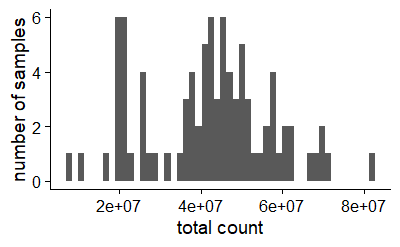

```r
plot_total_counts(dds)
```

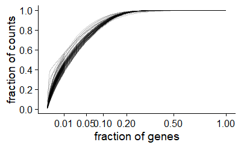

```r
plot_library_complexity(dds)
```

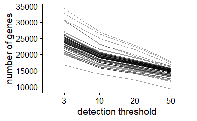

```r
plot_gene_detection(dds)
```

Perform gene filtering.

We determined `min_count` empirically by looking at the red trend line in the variance stabilization plot. Ideally, this trend line should be flat (i.e., stable).

- Not setting any `min_count` resulted in a steep, upward-sloping trend line.
- Setting it to 5 also resulted in a steep, upward-sloping trend line.

```r
dds <- filter_genes(dds, min_count = 10)
```

Transform the read counts.

From https://chipster.csc.fi/manual/deseq2-transform.html:  
You can use the resulting transformed values only for visualization and clustering, not for differential expression analysis which needs raw counts.

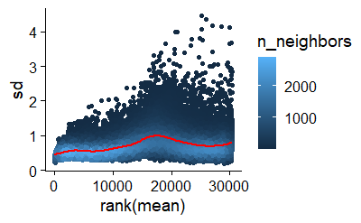

```r
vsd <- vst(dds)
mean_sd_plot(vsd)
```

Check the clustering of the samples.

If you encounter the error

```
Error in loadNamespace(x) : there is no package called
              'ComplexHeatmap'
```

, uncomment and run the following code block:

```r
# install.packages("devtools", dependencies = TRUE)
# devtools::install_github("jokergoo/ComplexHeatmap")
```

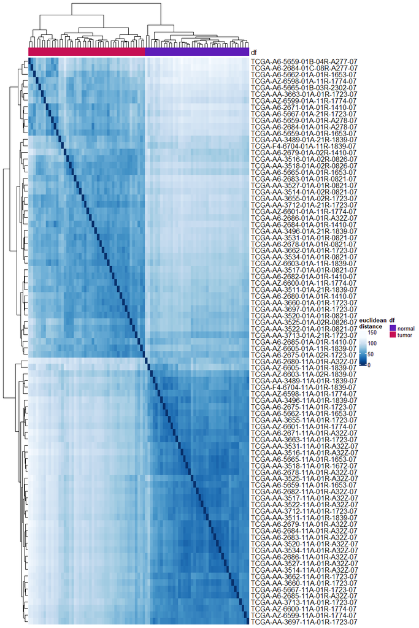

```r
set.seed(42)
plot_sample_clustering(vsd, anno_vars = c("type"), distance = "euclidean")
```

Perform principal component analysis (PCA).

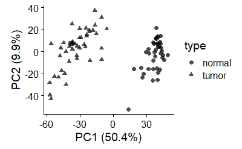

```r
plot_pca(vsd, PC_x = 1, PC_y = 2, shape_by = "type")
```

### Regulated Cell Death

Refer to `1. Exploratory Data Analysis - MSigDB Gene Sets + GTEx TPM.Rmd` for more detailed documentation on obtaining the gene sets.

#### Necroptosis

Fetch the necroptosis gene set.

```r
necroptosis.genes <- msigdbr(species = "human", category = "C5", subcategory = "GO:BP") %>%
  dplyr::filter(gs_name == "GOBP_NECROPTOTIC_SIGNALING_PATHWAY")
necroptosis.genes
```

| gs_cat | gs_subcat | gs_name | gene_symbol | entrez_gene | ensembl_gene | human_gene_symbol | human_entrez_gene | human_ensembl_gene | gs_id | gs_pmid | gs_geoid | gs_exact_source | gs_url | gs_description |
| --- | --- | --- | --- | --- | --- | --- | --- | --- | --- | --- | --- | --- | --- | --- |
| C5 | GO:BP | GOBP_NECROPTOTIC_SIGNALING_PATHWAY | FADD | 8772 | ENSG00000168040 | FADD | 8772 | ENSG00000168040 | M24779 |  |  | GO:0097527 | http://amigo.geneontology.org/amigo/term/GO:0097527 | A series of molecular signals which triggers the necroptotic death of a cell. The pathway starts with reception of a signal, is characterized by activation of receptor-interacting serine/threonine-pro… |
| C5 | GO:BP | GOBP_NECROPTOTIC_SIGNALING_PATHWAY | FAS | 355 | ENSG00000026103 | FAS | 355 | ENSG00000026103 | M24779 |  |  | GO:0097527 | http://amigo.geneontology.org/amigo/term/GO:0097527 | A series of molecular signals which triggers the necroptotic death of a cell. The pathway starts with reception of a signal, is characterized by activation of receptor-interacting serine/threonine-pro… |
| C5 | GO:BP | GOBP_NECROPTOTIC_SIGNALING_PATHWAY | FASLG | 356 | ENSG00000117560 | FASLG | 356 | ENSG00000117560 | M24779 |  |  | GO:0097527 | http://amigo.geneontology.org/amigo/term/GO:0097527 | A series of molecular signals which triggers the necroptotic death of a cell. The pathway starts with reception of a signal, is characterized by activation of receptor-interacting serine/threonine-pro… |
| C5 | GO:BP | GOBP_NECROPTOTIC_SIGNALING_PATHWAY | MLKL | 197259 | ENSG00000168404 | MLKL | 197259 | ENSG00000168404 | M24779 |  |  | GO:0097527 | http://amigo.geneontology.org/amigo/term/GO:0097527 | A series of molecular signals which triggers the necroptotic death of a cell. The pathway starts with reception of a signal, is characterized by activation of receptor-interacting serine/threonine-pro… |
| C5 | GO:BP | GOBP_NECROPTOTIC_SIGNALING_PATHWAY | RIPK1 | 8737 | ENSG00000137275 | RIPK1 | 8737 | ENSG00000137275 | M24779 |  |  | GO:0097527 | http://amigo.geneontology.org/amigo/term/GO:0097527 | A series of molecular signals which triggers the necroptotic death of a cell. The pathway starts with reception of a signal, is characterized by activation of receptor-interacting serine/threonine-pro… |
| C5 | GO:BP | GOBP_NECROPTOTIC_SIGNALING_PATHWAY | RIPK3 | 11035 | ENSG00000129465 | RIPK3 | 11035 | ENSG00000129465 | M24779 |  |  | GO:0097527 | http://amigo.geneontology.org/amigo/term/GO:0097527 | A series of molecular signals which triggers the necroptotic death of a cell. The pathway starts with reception of a signal, is characterized by activation of receptor-interacting serine/threonine-pro… |
| C5 | GO:BP | GOBP_NECROPTOTIC_SIGNALING_PATHWAY | RIPK3 | 11035 | ENSG00000285379 | RIPK3 | 11035 | ENSG00000285379 | M24779 |  |  | GO:0097527 | http://amigo.geneontology.org/amigo/term/GO:0097527 | A series of molecular signals which triggers the necroptotic death of a cell. The pathway starts with reception of a signal, is characterized by activation of receptor-interacting serine/threonine-pro… |
| C5 | GO:BP | GOBP_NECROPTOTIC_SIGNALING_PATHWAY | TLR3 | 7098 | ENSG00000164342 | TLR3 | 7098 | ENSG00000164342 | M24779 |  |  | GO:0097527 | http://amigo.geneontology.org/amigo/term/GO:0097527 | A series of molecular signals which triggers the necroptotic death of a cell. The pathway starts with reception of a signal, is characterized by activation of receptor-interacting serine/threonine-pro… |
| C5 | GO:BP | GOBP_NECROPTOTIC_SIGNALING_PATHWAY | TNF | 7124 | ENSG00000204490 | TNF | 7124 | ENSG00000204490 | M24779 |  |  | GO:0097527 | http://amigo.geneontology.org/amigo/term/GO:0097527 | A series of molecular signals which triggers the necroptotic death of a cell. The pathway starts with reception of a signal, is characterized by activation of receptor-interacting serine/threonine-pro… |
| C5 | GO:BP | GOBP_NECROPTOTIC_SIGNALING_PATHWAY | TNF | 7124 | ENSG00000206439 | TNF | 7124 | ENSG00000206439 | M24779 |  |  | GO:0097527 | http://amigo.geneontology.org/amigo/term/GO:0097527 | A series of molecular signals which triggers the necroptotic death of a cell. The pathway starts with reception of a signal, is characterized by activation of receptor-interacting serine/threonine-pro… |

[output cut: 6 more lines]

Filter the genes to include only those in the necroptosis gene set.

```r
rownames(necroptosis.genes) <- necroptosis.genes$ensembl_gene
```

```r
coad_necroptosis <- count_matrix[rownames(count_matrix) %in% necroptosis.genes$ensembl_gene, ]
coad_necroptosis <- coad_necroptosis[, rownames(samples)]

# Check if all samples in the counts dataframe are in the samples dataframe
all(colnames(coad_necroptosis) == rownames(samples))
```

Perform differential gene expression analysis.

```r
dds <- DESeqDataSetFromMatrix(
  countData = coad_necroptosis,
  colData = samples,
  design = ~type
)
dds <- filter_genes(dds, min_count = 10)
dds$type <- relevel(dds$type, ref = "normal")
dds <- DESeq(dds)
res <- results(dds)
summary(res)
```

```
out of 8 with nonzero total read count
adjusted p-value < 0.1
LFC > 0 (up)       : 2, 25%
LFC < 0 (down)     : 2, 25%
outliers [1]       : 0, 0%
low counts [2]     : 0, 0%
(mean count < 38)
[1] see 'cooksCutoff' argument of ?results
[2] see 'independentFiltering' argument of ?results
```

Prettify the display of results.

```r
deseq.results <- res
deseq.bbl.data <- data.frame(
  row.names = rownames(deseq.results),
  baseMean = deseq.results$baseMean,
  log2FoldChange = deseq.results$log2FoldChange,
  lfcSE = deseq.results$lfcSE,
  stat = deseq.results$stat,
  pvalue = deseq.results$pvalue,
  padj = deseq.results$padj,
  cancer_type = "Colon",
  gene_symbol = necroptosis.genes[rownames(deseq.results), "gene_symbol"]
)
deseq.bbl.data
```

|  | baseMean | log2FoldChange | lfcSE | stat | pvalue | padj | cancer_type | gene_symbol |
| --- | --- | --- | --- | --- | --- | --- | --- | --- |
| ENSG00000026103 | 812.79586 | -0.73365309 | 0.14226324 | -5.1570108 | 2.509233e-07 | 5.018467e-07 | Colon | FAS |
| ENSG00000117560 | 38.30547 | -0.44096237 | 0.23973882 | -1.8393449 | 6.586447e-02 | 1.053832e-01 | Colon | FASLG |
| ENSG00000129465 | 781.31915 | -0.17273184 | 0.11077023 | -1.5593706 | 1.189087e-01 | 1.585449e-01 | Colon | RIPK3 |
| ENSG00000137275 | 2029.09878 | -0.06117223 | 0.07569339 | -0.8081581 | 4.189996e-01 | 4.189996e-01 | Colon | RIPK1 |
| ENSG00000164342 | 803.91169 | -1.40923474 | 0.15158016 | -9.2969602 | 1.445183e-20 | 5.780733e-20 | Colon | TLR3 |
| ENSG00000168040 | 225.80844 | 1.26053718 | 0.17589965 | 7.1662289 | 7.709183e-13 | 2.055782e-12 | Colon | FADD |
| ENSG00000168404 | 974.98945 | 1.25144080 | 0.11550908 | 10.8341333 | 2.372010e-27 | 1.897608e-26 | Colon | MLKL |
| ENSG00000232810 | 49.37205 | 0.30058837 | 0.21221403 | 1.4164397 | 1.566468e-01 | 1.790249e-01 | Colon | TNF |

Plot the results.

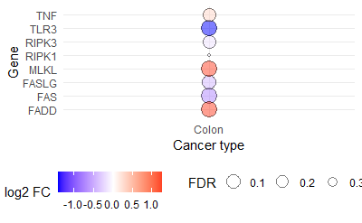

```r
ggplot(deseq.bbl.data, aes(x = cancer_type, y = gene_symbol, size = padj, fill = log2FoldChange)) +
  geom_point(alpha = 0.5, shape = 21, color = "black") +
  scale_size(trans = "reverse") +
  scale_fill_gradient2(low = "blue", mid = "white", high = "red", limits = c(min(deseq.bbl.data$log2FoldChange), max(deseq.bbl.data$log2FoldChange))) +
  theme_minimal() +
  theme(legend.position = "bottom") +
  theme(legend.position = "bottom") +
  labs(size = "FDR", fill = "log2 FC", x = "Cancer type", y = "Gene")
```

#### Ferroptosis

Fetch the ferroptosis gene set.

```r
ferroptosis.genes <- msigdbr(species = "human", category = "C2", subcategory = "CP:WIKIPATHWAYS") %>%
  dplyr::filter(gs_name == "WP_FERROPTOSIS")
ferroptosis.genes
```

| gs_cat | gs_subcat | gs_name | gene_symbol | entrez_gene | ensembl_gene | human_gene_symbol | human_entrez_gene | human_ensembl_gene | gs_id | gs_pmid | gs_geoid | gs_exact_source | gs_url | gs_description |
| --- | --- | --- | --- | --- | --- | --- | --- | --- | --- | --- | --- | --- | --- | --- |
| C2 | CP:WIKIPATHWAYS | WP_FERROPTOSIS | ACSL1 | 2180 | ENSG00000151726 | ACSL1 | 2180 | ENSG00000151726 | M39768 |  |  | WP4313 | http://www.wikipathways.org/instance/WP4313_r120500 | Ferroptosis |
| C2 | CP:WIKIPATHWAYS | WP_FERROPTOSIS | ACSL3 | 2181 | ENSG00000123983 | ACSL3 | 2181 | ENSG00000123983 | M39768 |  |  | WP4313 | http://www.wikipathways.org/instance/WP4313_r120500 | Ferroptosis |
| C2 | CP:WIKIPATHWAYS | WP_FERROPTOSIS | ACSL4 | 2182 | ENSG00000068366 | ACSL4 | 2182 | ENSG00000068366 | M39768 |  |  | WP4313 | http://www.wikipathways.org/instance/WP4313_r120500 | Ferroptosis |
| C2 | CP:WIKIPATHWAYS | WP_FERROPTOSIS | ACSL5 | 51703 | ENSG00000197142 | ACSL5 | 51703 | ENSG00000197142 | M39768 |  |  | WP4313 | http://www.wikipathways.org/instance/WP4313_r120500 | Ferroptosis |
| C2 | CP:WIKIPATHWAYS | WP_FERROPTOSIS | ACSL6 | 23305 | ENSG00000164398 | ACSL6 | 23305 | ENSG00000164398 | M39768 |  |  | WP4313 | http://www.wikipathways.org/instance/WP4313_r120500 | Ferroptosis |
| C2 | CP:WIKIPATHWAYS | WP_FERROPTOSIS | AIFM2 | 84883 | ENSG00000042286 | AIFM2 | 84883 | ENSG00000042286 | M39768 |  |  | WP4313 | http://www.wikipathways.org/instance/WP4313_r120500 | Ferroptosis |
| C2 | CP:WIKIPATHWAYS | WP_FERROPTOSIS | AKR1C1 | 1645 | ENSG00000187134 | AKR1C1 | 1645 | ENSG00000187134 | M39768 |  |  | WP4313 | http://www.wikipathways.org/instance/WP4313_r120500 | Ferroptosis |
| C2 | CP:WIKIPATHWAYS | WP_FERROPTOSIS | AKR1C2 | 1646 | ENSG00000151632 | AKR1C2 | 1646 | ENSG00000151632 | M39768 |  |  | WP4313 | http://www.wikipathways.org/instance/WP4313_r120500 | Ferroptosis |
| C2 | CP:WIKIPATHWAYS | WP_FERROPTOSIS | AKR1C3 | 8644 | ENSG00000196139 | AKR1C3 | 8644 | ENSG00000196139 | M39768 |  |  | WP4313 | http://www.wikipathways.org/instance/WP4313_r120500 | Ferroptosis |
| C2 | CP:WIKIPATHWAYS | WP_FERROPTOSIS | ALOX15 | 246 | ENSG00000161905 | ALOX15 | 246 | ENSG00000161905 | M39768 |  |  | WP4313 | http://www.wikipathways.org/instance/WP4313_r120500 | Ferroptosis |

[output cut: 56 more lines]

Filter the genes to include only those in the ferroptosis gene set.

```r
rownames(ferroptosis.genes) <- ferroptosis.genes$ensembl_gene
```

```r
coad_ferroptosis <- count_matrix[rownames(count_matrix) %in% ferroptosis.genes$ensembl_gene, ]
coad_ferroptosis <- coad_ferroptosis[, rownames(samples)]

# Check if all samples in the counts dataframe are in the samples dataframe
all(colnames(coad_ferroptosis) == rownames(samples))
```

Perform differential gene expression analysis.

```r
dds <- DESeqDataSetFromMatrix(
  countData = coad_ferroptosis,
  colData = samples,
  design = ~type
)
dds <- filter_genes(dds, min_count = 10)
dds$type <- relevel(dds$type, ref = "normal")
dds <- DESeq(dds)
```

```
-- replacing outliers and refitting for 2 genes
-- DESeq argument 'minReplicatesForReplace' = 7
-- original counts are preserved in counts(dds)
```

```r
res <- results(dds)
summary(res)
```

```
out of 63 with nonzero total read count
adjusted p-value < 0.1
LFC > 0 (up)       : 24, 38%
LFC < 0 (down)     : 19, 30%
outliers [1]       : 0, 0%
low counts [2]     : 0, 0%
(mean count < 8)
[1] see 'cooksCutoff' argument of ?results
[2] see 'independentFiltering' argument of ?results
```

Prettify the display of results.

```r
deseq.results <- res
deseq.bbl.data <- data.frame(
  row.names = rownames(deseq.results),
  baseMean = deseq.results$baseMean,
  log2FoldChange = deseq.results$log2FoldChange,
  lfcSE = deseq.results$lfcSE,
  stat = deseq.results$stat,
  pvalue = deseq.results$pvalue,
  padj = deseq.results$padj,
  cancer_type = "Colon",
  gene_symbol = ferroptosis.genes[rownames(deseq.results), "gene_symbol"]
)
deseq.bbl.data
```

|  | baseMean | log2FoldChange | lfcSE | stat | pvalue | padj | cancer_type | gene_symbol |
| --- | --- | --- | --- | --- | --- | --- | --- | --- |
| ENSG00000001084 | 1609.796938 | 0.27213638 | 0.09212937 | 2.9538504 | 3.138361e-03 | 5.991417e-03 | Colon | GCLC |
| ENSG00000007952 | 5983.418730 | 0.91964628 | 0.21911692 | 4.1970574 | 2.704054e-05 | 7.098141e-05 | Colon | NOX1 |
| ENSG00000023909 | 862.075603 | 0.27095805 | 0.13741073 | 1.9718843 | 4.862282e-02 | 7.293423e-02 | Colon | GCLM |
| ENSG00000042286 | 1687.876818 | 0.09091204 | 0.13241555 | 0.6865662 | 4.923562e-01 | 5.539007e-01 | Colon | AIFM2 |
| ENSG00000047457 | 285.842538 | -2.65419858 | 0.25135775 | -10.5594460 | 4.593651e-26 | 5.788000e-25 | Colon | CP |
| ENSG00000057663 | 2016.155121 | -0.18976202 | 0.07644660 | -2.4822820 | 1.305439e-02 | 2.164281e-02 | Colon | ATG5 |
| ENSG00000068366 | 1927.113505 | 1.07139023 | 0.15248226 | 7.0263269 | 2.120414e-12 | 9.541863e-12 | Colon | ACSL4 |
| ENSG00000072274 | 14407.740951 | 0.72101146 | 0.14308965 | 5.0388792 | 4.682659e-07 | 1.638931e-06 | Colon | TFRC |
| ENSG00000078668 | 4461.690405 | 0.13351365 | 0.09264708 | 1.4410994 | 1.495566e-01 | 1.922871e-01 | Colon | VDAC3 |
| ENSG00000079459 | 8507.872357 | 0.44946639 | 0.11347789 | 3.9608280 | 7.469032e-05 | 1.882196e-04 | Colon | FDFT1 |

[output cut: 53 more lines]

Plot the results.

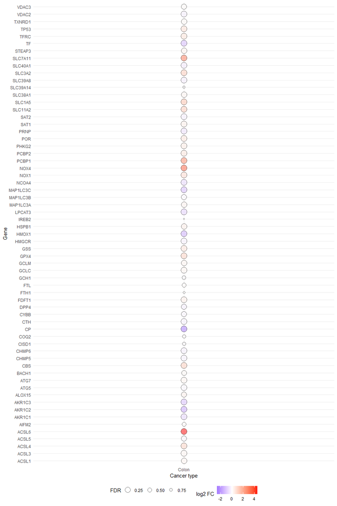

```r
ggplot(deseq.bbl.data, aes(x = cancer_type, y = gene_symbol, size = padj, fill = log2FoldChange)) +
  geom_point(alpha = 0.5, shape = 21, color = "black") +
  scale_size(trans = "reverse") +
  scale_fill_gradient2(low = "blue", mid = "white", high = "red", limits = c(min(deseq.bbl.data$log2FoldChange), max(deseq.bbl.data$log2FoldChange))) +
  theme_minimal() +
  theme(legend.position = "bottom") +
  theme(legend.position = "bottom") +
  labs(size = "FDR", fill = "log2 FC", x = "Cancer type", y = "Gene")
```

#### Pyroptosis

Fetch the pyroptosis gene set.

```r
pyroptosis.genes <- msigdbr(species = "human", category = "C2", subcategory = "CP:REACTOME") %>%
  dplyr::filter(gs_name == "REACTOME_PYROPTOSIS")
pyroptosis.genes
```

| gs_cat | gs_subcat | gs_name | gene_symbol | entrez_gene | ensembl_gene | human_gene_symbol | human_entrez_gene | human_ensembl_gene | gs_id | gs_pmid | gs_geoid | gs_exact_source | gs_url | gs_description |
| --- | --- | --- | --- | --- | --- | --- | --- | --- | --- | --- | --- | --- | --- | --- |
| C2 | CP:REACTOME | REACTOME_PYROPTOSIS | BAK1 | 578 | ENSG00000030110 | BAK1 | 578 | ENSG00000030110 | M41805 |  |  | R-HSA-5620971 | https://www.reactome.org/content/detail/R-HSA-5620971\|https://reactome.org/PathwayBrowser/#/R-HSA-5620971 | Pyroptosis |
| C2 | CP:REACTOME | REACTOME_PYROPTOSIS | BAX | 581 | ENSG00000087088 | BAX | 581 | ENSG00000087088 | M41805 |  |  | R-HSA-5620971 | https://www.reactome.org/content/detail/R-HSA-5620971\|https://reactome.org/PathwayBrowser/#/R-HSA-5620971 | Pyroptosis |
| C2 | CP:REACTOME | REACTOME_PYROPTOSIS | CASP1 | 834 | ENSG00000137752 | CASP1 | 834 | ENSG00000137752 | M41805 |  |  | R-HSA-5620971 | https://www.reactome.org/content/detail/R-HSA-5620971\|https://reactome.org/PathwayBrowser/#/R-HSA-5620971 | Pyroptosis |
| C2 | CP:REACTOME | REACTOME_PYROPTOSIS | CASP3 | 836 | ENSG00000164305 | CASP3 | 836 | ENSG00000164305 | M41805 |  |  | R-HSA-5620971 | https://www.reactome.org/content/detail/R-HSA-5620971\|https://reactome.org/PathwayBrowser/#/R-HSA-5620971 | Pyroptosis |
| C2 | CP:REACTOME | REACTOME_PYROPTOSIS | CASP4 | 837 | ENSG00000196954 | CASP4 | 837 | ENSG00000196954 | M41805 |  |  | R-HSA-5620971 | https://www.reactome.org/content/detail/R-HSA-5620971\|https://reactome.org/PathwayBrowser/#/R-HSA-5620971 | Pyroptosis |
| C2 | CP:REACTOME | REACTOME_PYROPTOSIS | CASP5 | 838 | ENSG00000137757 | CASP5 | 838 | ENSG00000137757 | M41805 |  |  | R-HSA-5620971 | https://www.reactome.org/content/detail/R-HSA-5620971\|https://reactome.org/PathwayBrowser/#/R-HSA-5620971 | Pyroptosis |
| C2 | CP:REACTOME | REACTOME_PYROPTOSIS | CHMP2A | 27243 | ENSG00000130724 | CHMP2A | 27243 | ENSG00000130724 | M41805 |  |  | R-HSA-5620971 | https://www.reactome.org/content/detail/R-HSA-5620971\|https://reactome.org/PathwayBrowser/#/R-HSA-5620971 | Pyroptosis |
| C2 | CP:REACTOME | REACTOME_PYROPTOSIS | CHMP2B | 25978 | ENSG00000083937 | CHMP2B | 25978 | ENSG00000083937 | M41805 |  |  | R-HSA-5620971 | https://www.reactome.org/content/detail/R-HSA-5620971\|https://reactome.org/PathwayBrowser/#/R-HSA-5620971 | Pyroptosis |
| C2 | CP:REACTOME | REACTOME_PYROPTOSIS | CHMP3 | 51652 | ENSG00000115561 | CHMP3 | 51652 | ENSG00000115561 | M41805 |  |  | R-HSA-5620971 | https://www.reactome.org/content/detail/R-HSA-5620971\|https://reactome.org/PathwayBrowser/#/R-HSA-5620971 | Pyroptosis |
| C2 | CP:REACTOME | REACTOME_PYROPTOSIS | CHMP4A | 29082 | ENSG00000254505 | CHMP4A | 29082 | ENSG00000254505 | M41805 |  |  | R-HSA-5620971 | https://www.reactome.org/content/detail/R-HSA-5620971\|https://reactome.org/PathwayBrowser/#/R-HSA-5620971 | Pyroptosis |

[output cut: 20 more lines]

Filter the genes to include only those in the pyroptosis gene set.

```r
rownames(pyroptosis.genes) <- pyroptosis.genes$ensembl_gene
```

```r
coad_pyroptosis <- count_matrix[rownames(count_matrix) %in% pyroptosis.genes$ensembl_gene, ]
coad_pyroptosis <- coad_pyroptosis[, rownames(samples)]

# Check if all samples in the counts dataframe are in the samples dataframe
all(colnames(coad_pyroptosis) == rownames(samples))
```

Perform differential gene expression analysis.

```r
dds <- DESeqDataSetFromMatrix(
  countData = coad_pyroptosis,
  colData = samples,
  design = ~type
)
dds <- filter_genes(dds, min_count = 10)
dds$type <- relevel(dds$type, ref = "normal")
dds <- DESeq(dds)
```

```
-- replacing outliers and refitting for 1 genes
-- DESeq argument 'minReplicatesForReplace' = 7
-- original counts are preserved in counts(dds)
```

```r
res <- results(dds)
summary(res)
```

```
out of 27 with nonzero total read count
adjusted p-value < 0.1
LFC > 0 (up)       : 10, 37%
LFC < 0 (down)     : 7, 26%
outliers [1]       : 0, 0%
low counts [2]     : 0, 0%
(mean count < 16)
[1] see 'cooksCutoff' argument of ?results
[2] see 'independentFiltering' argument of ?results
```

Prettify the display of results.

```r
deseq.results <- res
deseq.bbl.data <- data.frame(
  row.names = rownames(deseq.results),
  baseMean = deseq.results$baseMean,
  log2FoldChange = deseq.results$log2FoldChange,
  lfcSE = deseq.results$lfcSE,
  stat = deseq.results$stat,
  pvalue = deseq.results$pvalue,
  padj = deseq.results$padj,
  cancer_type = "Colon",
  gene_symbol = pyroptosis.genes[rownames(deseq.results), "gene_symbol"]
)
deseq.bbl.data
```

|  | baseMean | log2FoldChange | lfcSE | stat | pvalue | padj | cancer_type | gene_symbol |
| --- | --- | --- | --- | --- | --- | --- | --- | --- |
| ENSG00000030110 | 2013.25240 | -0.43898301 | 0.10896636 | -4.02861040 | 5.610751e-05 | 1.262419e-04 | Colon | BAK1 |
| ENSG00000073282 | 17.20881 | -0.28792091 | 0.27446722 | -1.04901747 | 2.941701e-01 | 3.782187e-01 | Colon | TP63 |
| ENSG00000083937 | 3350.36637 | -0.23578112 | 0.11826377 | -1.99368854 | 4.618610e-02 | 7.335440e-02 | Colon | CHMP2B |
| ENSG00000087088 | 3000.78182 | 0.71053151 | 0.14189535 | 5.00743351 | 5.516060e-07 | 1.489336e-06 | Colon | BAX |
| ENSG00000100453 | 367.99014 | 2.57443809 | 0.26750266 | 9.62397185 | 6.333714e-22 | 5.700343e-21 | Colon | GZMB |
| ENSG00000101421 | 12139.29731 | 0.20091672 | 0.13183220 | 1.52403373 | 1.275003e-01 | 1.855957e-01 | Colon | CHMP4B |
| ENSG00000104518 | 3931.12267 | 0.25220618 | 0.16980753 | 1.48524730 | 1.374783e-01 | 1.855957e-01 | Colon | GSDMD |
| ENSG00000105928 | 179.98184 | 0.86953040 | 0.26030280 | 3.34045736 | 8.364052e-04 | 1.613067e-03 | Colon | GSDME |
| ENSG00000115008 | 54.20766 | 2.96291009 | 0.30282911 | 9.78409938 | 1.317631e-22 | 1.778802e-21 | Colon | IL1A |
| ENSG00000115561 | 4033.18955 | -0.03831356 | 0.11533213 | -0.33220195 | 7.397368e-01 | 7.681882e-01 | Colon | CHMP3 |

[output cut: 17 more lines]

Plot the results.

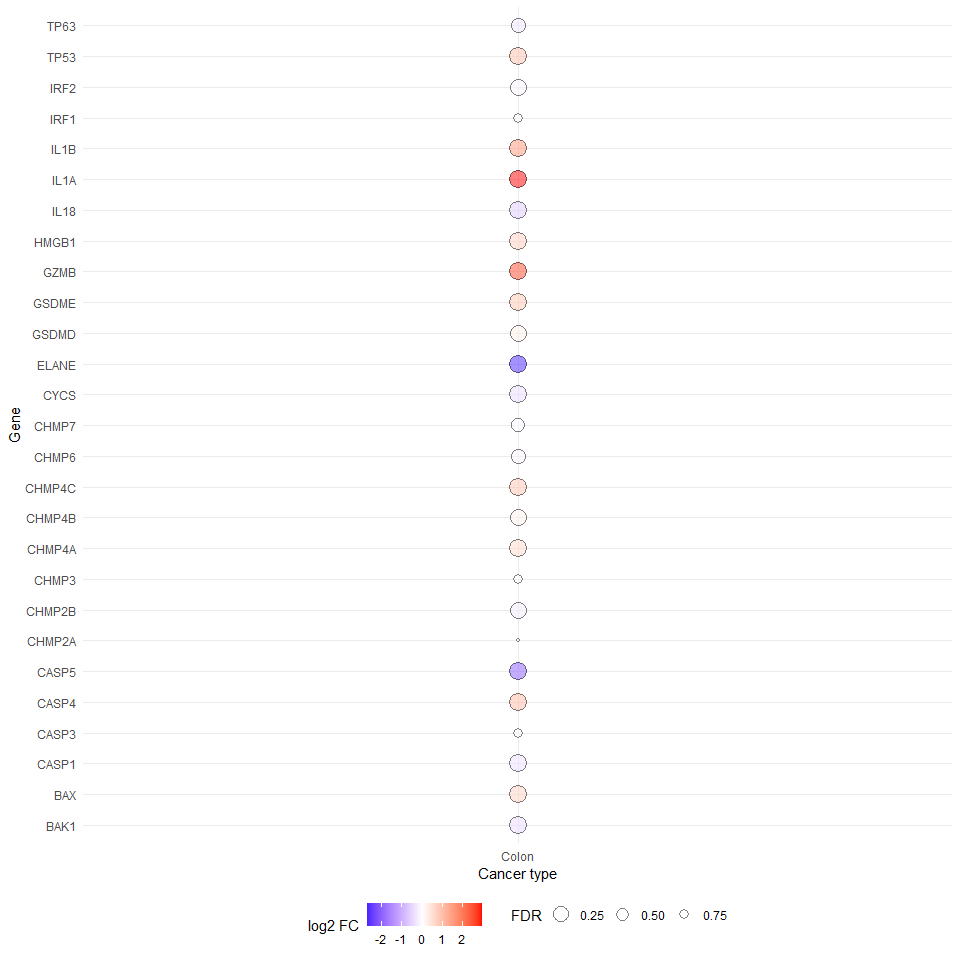

```r
ggplot(deseq.bbl.data, aes(x = cancer_type, y = gene_symbol, size = padj, fill = log2FoldChange)) +
  geom_point(alpha = 0.5, shape = 21, color = "black") +
  scale_size(trans = "reverse") +
  scale_fill_gradient2(low = "blue", mid = "white", high = "red", limits = c(min(deseq.bbl.data$log2FoldChange), max(deseq.bbl.data$log2FoldChange))) +
  theme_minimal() +
  theme(legend.position = "bottom") +
  theme(legend.position = "bottom") +
  labs(size = "FDR", fill = "log2 FC", x = "Cancer type", y = "Gene")
```

[^1]: De La Salle University, Manila, Philippines, kim_leejra@dlsu.edu.ph
[^2]: De La Salle University, Manila, Philippines, gonzales.markedward@gmail.com
[^3]: De La Salle University, Manila, Philippines, anish.shrestha@dlsu.edu.ph